# Pre-Assessment_02

22/03/2022

## What the data? - data source

- RKI => Robert Koch Institute
- “SARS-CoV-2_Infektionen_in_Deutschland”

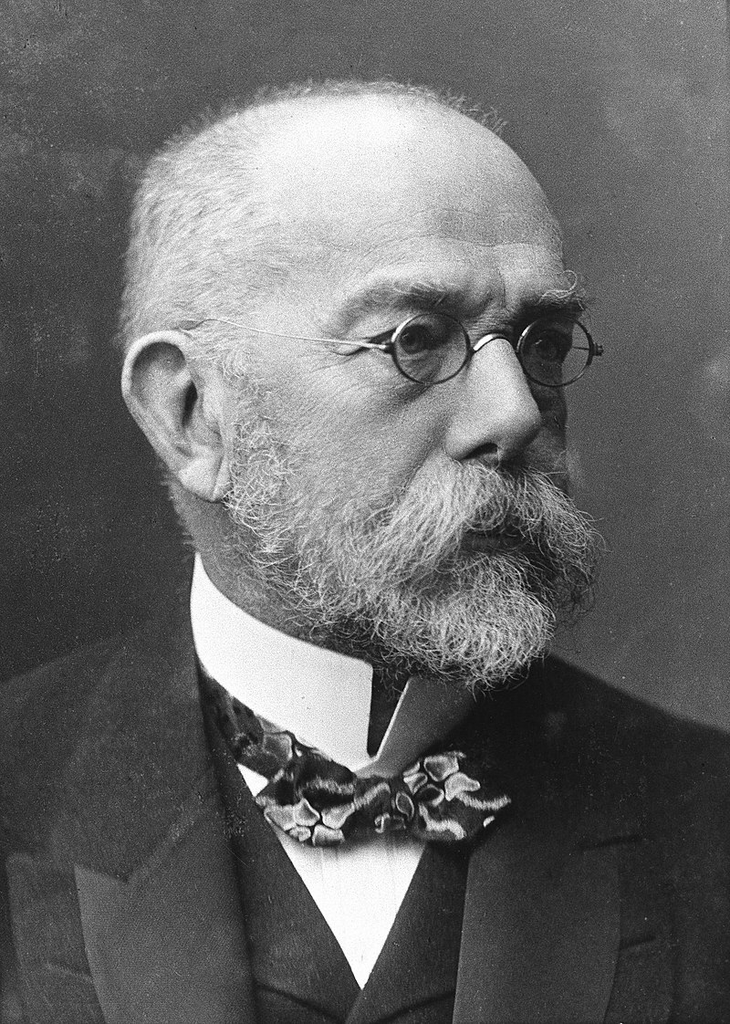

Robert Koch 1842 - 1910

## What the data?! - context

- Roughly: Documents recorded and transmitted infection for the whole of the FRG
- updated at least once in 24h
- 1 *.csv*-file cumulating all cases up to that point
- UTF-8 for symbols
- ISO8601 for date
- public record available at
  - https://github.com/orgs/robert-koch-institut/repositories
- maintained centrally and internally

## What the data?! - sneak peek

```r
wk_5_inf <- data.table::fread("/home/jpv/Documents/Uni/D.Proc.Vis/rStudioWD/covid_frg_project/SARS-CoV-2_Infektionen_in_Deutschland/Aktuell_Deutschland_SarsCov2_Infektionen.csv")
head(wk_5_inf, 1)
```

```
##    IdLandkreis Altersgruppe Geschlecht Meldedatum   Refdatum
## 1:        1001      A15-A34          M 2020-10-28 2020-01-19
##    IstErkrankungsbeginn NeuerFall NeuerTodesfall NeuGenesen AnzahlFall
## 1:                    1         0             -9          0          1
##    AnzahlTodesfall AnzahlGenesen
## 1:               0             1
```

- location
- demographics
- timestamps
- ‘cardinalities’
- status

## What the data?! - variables

### **Location Indicator(s)**

#### **IdLandkreis**

- 4 - 6 digit codes shows where case has been reported from
- breaks data down by **location**
  1. Federal State
  2. Region
  3. Municipality

## What the data?! - variables

### **Demographic Indicators**

#### **Altersgruppe**

- breaks data down by **age brackets**
- E.g.: ‘A15-A34’ means recorded cases in that row are within that bracket
- ‘unbekannt’ -> uknown
- There are 7 age brackets: 0-4, 5-14, 15-34, 35-59, 60-79, 80+, unknown

#### **Geschlecht**

- breaks data down by **sex**
- E.g.: M -> male; W -> female; (unbekannt) -> uknown

## What the data?! - variables

### **Temporals**

#### **Meldedatum**

- breaks data down by **date of infection *report***
- I.e.: When the local health authority was made aware of the infection

#### **Refdatum**

- breaks data down by **date of infection**
- I.e.: When the disease was first confirmed
- Needn’t necessarily coincide with *Meldedatum*

## What the data?! - variables

### **Cardinality**

#### **AnzahlFall**

- **Amount if infections** in a corresponding case-group

#### **AnzahlTodesfall**

- **Amount of deaths** in a corresponding case-group

#### **AnzahlGenesen**

- **Amount of recoveries** in a corresponding case-group

NB: negative numbers are corrections of previously wrongly reported incidents

## What the data?! - variables

### **Status**

- Updates the status of existing case-groups
- may be -1, 0, 1 or -9

#### **NeuerFall**

- adds a **new infection** to a corresponding case-group

#### **NeuerTodesfall**

- adds a **new death** to a corresponding case-group

#### **NeuGenesen**

- adds a **new recovery** to a corresponding case-group

## Reading Data - The first week of February

### Loading dplyr

## Reading Data - The first week of February

### Importing data

```r
data_inf <- data.table::fread("/home/jpv/Documents/Uni/D.Proc.Vis/rStudioWD/covid_frg_project/SARS-CoV-2_Infektionen_in_Deutschland/Aktuell_Deutschland_SarsCov2_Infektionen.csv")
```

### Filtering by city: Hamburg (IdLandkreis == 2000)

```r
data_inf_HH <- data_inf %>% filter(IdLandkreis == 2000)
```

### Filtering by first week of February

```r
data_inf_wk_5_HH <- data_inf_HH %>% filter(Meldedatum == "2022-01-31" |
                                           Meldedatum == "2022-02-01" |
                                           Meldedatum == "2022-02-02" |
                                           Meldedatum == "2022-02-03" |
                                           Meldedatum == "2022-02-04" |
                                           Meldedatum == "2022-02-05" |
                                           Meldedatum == "2022-02-07")
```

## Reading Data - sneak peak at the first week of February in HH

```r
slice_sample(data_inf_wk_5_HH, n = 3)
```

```
##    IdLandkreis Altersgruppe Geschlecht Meldedatum   Refdatum
## 1:        2000      A15-A34          M 2022-01-31 2022-01-24
## 2:        2000      A60-A79          W 2022-02-04 2022-02-04
## 3:        2000      A15-A34          W 2022-01-31 2022-01-30
##    IstErkrankungsbeginn NeuerFall NeuerTodesfall NeuGenesen AnzahlFall
## 1:                    1         0             -9          0          1
## 2:                    0         0             -9          0        138
## 3:                    1         0             -9          0          6
##    AnzahlTodesfall AnzahlGenesen
## 1:               0             1
## 2:               0           138
## 3:               0             6
```

## Exploring the first week of February in HH

### deploying ggplot2

```r
library(ggplot2)
```

## Exploring the first week of February in HH

###### What were the amounts of reported cases per age bracket in the mean?

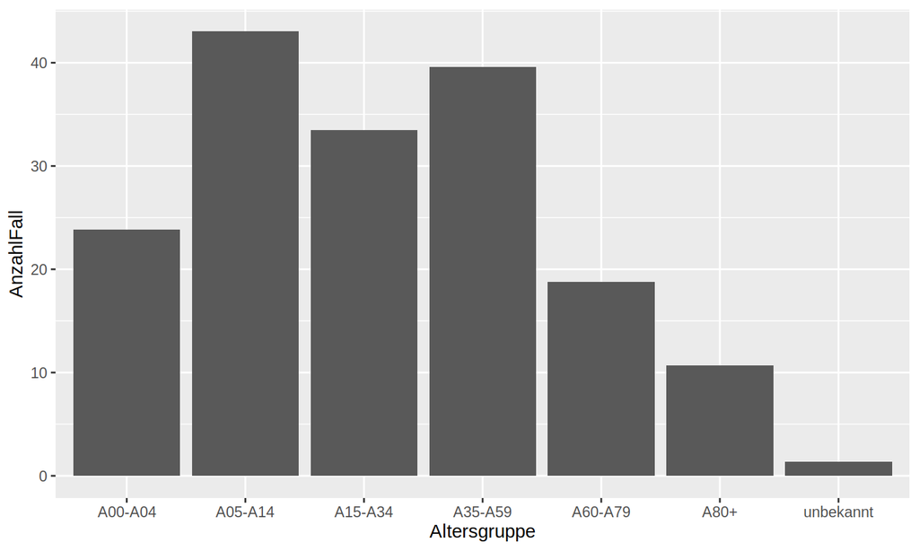

```r
ggplot(data_inf_wk_5_HH, aes(x = Altersgruppe, y = AnzahlFall)) +
geom_bar(stat = "summary_bin", fun = mean)
```

## Exploring the first week of February in HH

##### First confirmed cases

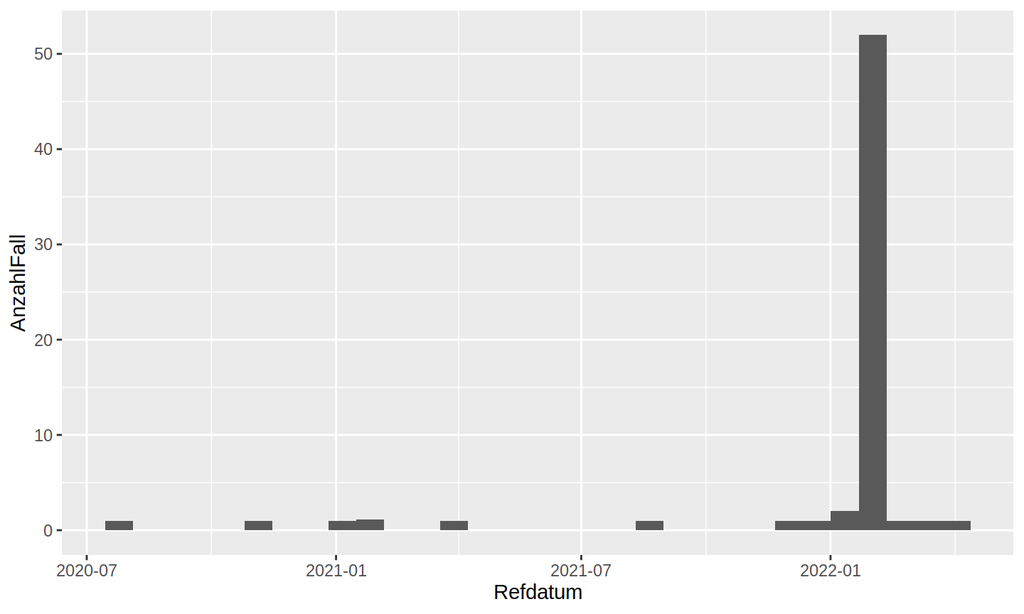

```r
ggplot(data_inf_wk_5_HH, aes(x = Refdatum, y = AnzahlFall)) +
geom_bar(stat = "summary_bin", fun = mean)
```

## Exploring the first week of February in HH

### Interesting Observation

```r
mean(data_inf_wk_5_HH$AnzahlFall)
```

```
## [1] 33.10512
```

```r
median(data_inf_wk_5_HH$AnzahlFall)
```

```
## [1] 2
```

## Problems that I am having

- Managing RAM in RStudio…
- A mix between not completely getting the logic and reason of the dataset as such
- Serious lack of expressing my intentions in R to (dis)prove assumptions about how the dataset works
- Difference between how the dataset formally and informally works (assumptions and interpretation?!)
- Extreme high granularity of data = > long time frame for analysis needed (not really a problem)